# Data analysis

📎 simulated_covid 📎 cleaned_vacdata

## R project

### Tạo Project trong R Studio

R project là một thư mục với file `.Rproj` . Để thuận tiện cho việc quản lý code và dữ liệu, ta nên tạo R project cho mỗi nghiên cứu/ báo cáo.

Quá trình tạo R project như sau:

- Vào menu **`File` > `New Project`**
- Bấm **`New Directory` >** **`New Project`**
- Điền tên folder cho R Project tại mục **`Directory name`**
- Bấm **`Browse`** và chọn Desktop để lưu R project tại Desktop
- Bấm **`Create Project`**

### Cấu trúc của một Project

Cấu trúc của một R project sẽ có định dạng như sau:

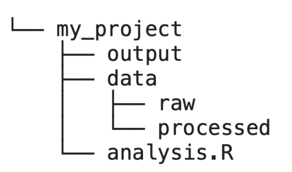

- `data` thư mục chứa dữ liệu cần phân tích
- `output` lưu trữ đầu ra mã (cốt truyện, số liệu, v.v.)
- `analysis.R` là tệp chứa mã R. Có thể có nhiều file `.R` trong 1 project.

### R markdown

File `.Rmd` thường được dùng cho báo cáo vì có thể kết hợp các lệnh R, văn bản thường, đồ thị trong 1 file

Gồm 3 phần chính:

- Phần YAML header: nằm ở trên cùng trong và ngăn cách với phần còn lại bằng cặp dấu `---`. Phần này để mô tả tiêu đề tài liệu, tác giả, ngày tháng, định dạng mong muốn
- Phần văn bản (được viết bằng ngôn ngữ **markdown**)
- Phần lệnh R (được gọi là **chunk**). Phần kết quả của câu lệnh R (chunk output) có thể hiển thị dưới dạng string, bảng dữ liệu hoặc đồ thị.

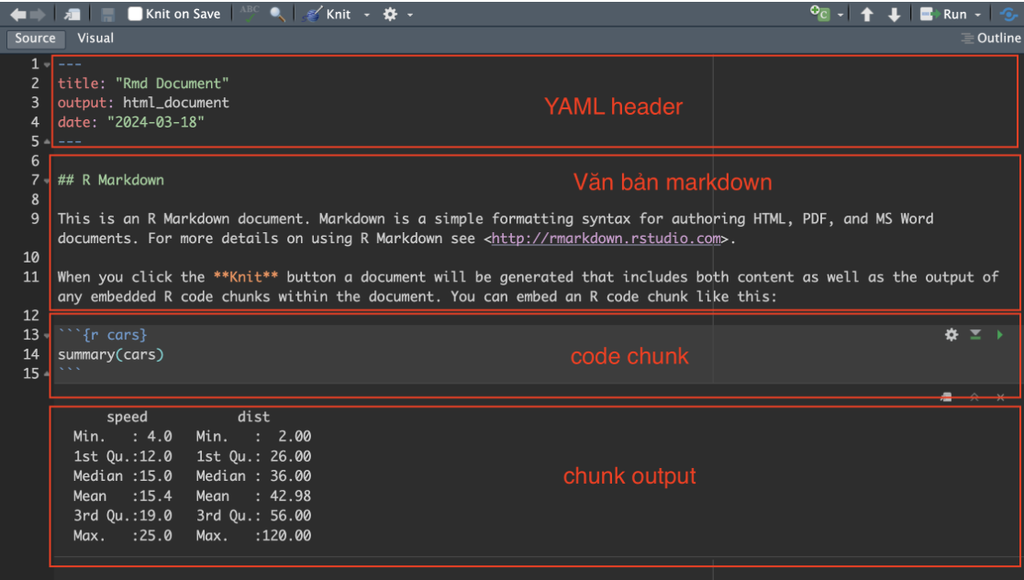

Tạo R Markdown bằng cách vào menu `File` > `New File` > `R Markdown...`

## Bảng phân tích thống kê

- Tải package: `tidyverse`, `gtsummary`
- Load package:

```r
library(tidyverse)
library(gtsummary)
```

Chúng ta sẽ sử dụng dữ liệu mô phỏng các ca bệnh Covid 19

```r
#linelist <- read_rds("https://raw.githubusercontent.com/HCDC-GSCB/swaper/main/data/simulated_covid.rds") %>% mutate_if(is.Date, ymd)

linelist <- read_rds("../data/simulated_covid.rds") %>% mutate_if(is.Date, ymd)
```

Dữ liệu bao gồm 2 đợt bùng phát dịch.

### gtsummary

Package gtsummary được dùng vẽ bảng thống kê một cách nhanh chóng bằng lệnh tbl_summary()

**VD:** sử dụng tbl_summary()

```r
linelist[,-2] %>% tbl_summary()
```

**Output**

| **Characteristic** | **N = 2,762**<sup>1</sup> |
| --- | --- |
| id | 1,320 (654, 2,017) |
| case_type |  |
| confirmed | 1,325 (48%) |
| probable | 879 (32%) |
| suspected | 558 (20%) |
| sex |  |
| f | 1,365 (49%) |
| m | 1,397 (51%) |
| age | 15 (8, 22) |
| date_onset | 2023-05-31 (2023-04-28, 2023-08-05) |
| date_admission | 2023-06-12 (NA, 2023-08-16) |
| Unknown | 2,206 |
| outcome |  |
| died | 220 (8.0%) |
| recovered | 2,542 (92%) |
| date_outcome | 2023-06-29 (2023-05-21, 2023-09-04) |
| Unknown | 2,542 |
| date_first_contact | 2023-05-28 (2023-04-25, 2023-08-03) |
| Unknown | 2 |
| date_last_contact | 2023-05-30 (2023-04-28, 2023-08-06) |
| Unknown | 2 |
| district |  |
| Binh Chanh | 126 (4.6%) |
| Binh Tan | 140 (5.1%) |
| Binh Thanh | 161 (5.8%) |
| Can Gio | 123 (4.5%) |
| Cu Chi | 88 (3.2%) |
| Go Vap | 119 (4.3%) |
| Hoc Mon | 99 (3.6%) |
| Nha Be | 84 (3.0%) |
| Phu Nhuan | 167 (6.0%) |
| Quan 1 | 120 (4.3%) |
| Quan 10 | 161 (5.8%) |
| Quan 11 | 159 (5.8%) |
| Quan 12 | 129 (4.7%) |
| Quan 3 | 115 (4.2%) |
| Quan 4 | 81 (2.9%) |
| Quan 5 | 130 (4.7%) |
| Quan 6 | 154 (5.6%) |
| Quan 7 | 46 (1.7%) |
| Quan 8 | 68 (2.5%) |
| Tan Binh | 152 (5.5%) |
| Tan Phu | 164 (5.9%) |
| Thu Duc | 176 (6.4%) |
| outbreak |  |
| 1st outbreak | 1,513 (55%) |
| 2nd outbreak | 1,249 (45%) |

<sup>1</sup> Median (Q1, Q3); n (%)

### Điều chỉnh bảng thống kê

Một số tham số của `tbl_summary` hỗ trợ điều chỉnh bảng thống kê

| Tên tham số | Công dụng |
| --- | --- |
| `include` | Chọn các biến được hiển thị trên bảng thống kê |
| `label` | Đổi cách hiển thị tên biến |
| `by` | Hiển thị thống kê nhóm theo giá trị của 1 biến |
| `statistic` | Điều chỉnh thống kê được hiển thị |

**Chọn các biến được thống kê qua tham số `include`**

```r
linelist %>%
  tbl_summary(
    include = c(age, sex, outcome, date_onset, date_admission, date_first_contact, date_last_contact, outbreak)
  )
```

| **Characteristic** | **N = 2,762**<sup>1</sup> |
| --- | --- |
| age | 15 (8, 22) |
| sex |  |
| f | 1,365 (49%) |
| m | 1,397 (51%) |
| outcome |  |
| died | 220 (8.0%) |
| recovered | 2,542 (92%) |
| date_onset | 2023-05-31 (2023-04-28, 2023-08-05) |
| date_admission | 2023-06-12 (NA, 2023-08-16) |
| Unknown | 2,206 |
| date_first_contact | 2023-05-28 (2023-04-25, 2023-08-03) |
| Unknown | 2 |
| date_last_contact | 2023-05-30 (2023-04-28, 2023-08-06) |
| Unknown | 2 |
| outbreak |  |
| 1st outbreak | 1,513 (55%) |
| 2nd outbreak | 1,249 (45%) |

<sup>1</sup> Median (Q1, Q3); n (%)

**Thay đổi tên biến qua tham số `label`**

**VD**: đổi tên được hiển thị cho các biến

```r
linelist %>% tbl_summary(
    include = c(age, sex, outcome, date_onset, date_admission,
                date_first_contact, date_last_contact, outbreak),
    # ----- Thay đổi cách hiển thị tên biến ------
    label = list(
      age ~ "Tuổi",
      sex ~ "Giới tính",
      outcome ~ "Kết quả",
      date_onset ~ "Ngày phát bệnh",
      date_admission ~ "Ngày nhập viện",
      date_first_contact ~ "Ngày tiếp xúc đầu tiên",
      date_last_contact ~ "Ngày tiếp xúc cuối cùng",
      outbreak ~ "Đợt dịch"
    )
  )
```

| **Characteristic** | **N = 2,762**<sup>1</sup> |
| --- | --- |
| Tuổi | 15 (8, 22) |
| Giới tính |  |
| f | 1,365 (49%) |
| m | 1,397 (51%) |
| Kết quả |  |
| died | 220 (8.0%) |
| recovered | 2,542 (92%) |
| Ngày phát bệnh | 2023-05-31 (2023-04-28, 2023-08-05) |
| Ngày nhập viện | 2023-06-12 (NA, 2023-08-16) |
| Unknown | 2,206 |
| Ngày tiếp xúc đầu tiên | 2023-05-28 (2023-04-25, 2023-08-03) |
| Unknown | 2 |
| Ngày tiếp xúc cuối cùng | 2023-05-30 (2023-04-28, 2023-08-06) |
| Unknown | 2 |
| Đợt dịch |  |
| 1st outbreak | 1,513 (55%) |
| 2nd outbreak | 1,249 (45%) |

<sup>1</sup> Median (Q1, Q3); n (%)

**Thống kê theo nhóm qua tham số `by`**

**VD:** hiện thống kê cho từng đợt dịch

```r
linelist %>% tbl_summary(
  include = c(age, sex, outcome, date_onset, date_admission,
                date_first_contact, date_last_contact, outbreak),
  label = list(
      age ~ "Tuổi",
      sex ~ "Giới tính",
      outcome ~ "Kết quả",
      date_onset ~ "Ngày phát bệnh",
      date_admission ~ "Ngày nhập viện",
      date_first_contact ~ "Ngày tiếp xúc đầu tiên",
      date_last_contact ~ "Ngày tiếp xúc cuối cùng"
    ),
  # ----- Hiển thị thống kê cho từng đợt dịch ------
  by = outbreak)
```

| **Characteristic** | **1st outbreak** N = 1,513<sup>1</sup> | **2nd outbreak** N = 1,249<sup>1</sup> |
| --- | --- | --- |
| Tuổi | 13 (6, 20) | 19 (10, 27) |
| Giới tính |  |  |
| f | 746 (49%) | 619 (50%) |
| m | 767 (51%) | 630 (50%) |
| Kết quả |  |  |
| died | 110 (7.3%) | 110 (8.8%) |
| recovered | 1,403 (93%) | 1,139 (91%) |
| Ngày phát bệnh | 2023-04-30 (2023-04-11, 2023-05-16) | 2023-08-12 (2023-07-16, 2023-08-31) |
| Ngày nhập viện | 2023-05-06 (2023-04-15, 2023-05-23) | 2023-08-18 (2023-07-25, 2023-09-05) |
| Unknown | 1,216 | 990 |
| Ngày tiếp xúc đầu tiên | 2023-04-27 (2023-04-08, 2023-05-13) | 2023-08-09 (2023-07-12, 2023-08-28) |
| Unknown | 1 | 1 |
| Ngày tiếp xúc cuối cùng | 2023-04-30 (2023-04-11, 2023-05-16) | 2023-08-11 (2023-07-15, 2023-08-31) |
| Unknown | 1 | 1 |

<sup>1</sup> Median (Q1, Q3); n (%)

**Điều chỉnh thống kê được hiển thị qua tham số `statistic`**

Người dùng có thể lựa chọn các phép thống kê để áp dụng lên các biến

**VD:** format thống kê cho `sex` và `outcome`

```r
linelist %>% tbl_summary(
  include = c(age, sex, outcome, date_onset, date_admission,
                date_first_contact, date_last_contact, outbreak),
  label = list(
      age ~ "Tuổi",
      sex ~ "Giới tính",
      outcome ~ "Kết quả",
      date_onset ~ "Ngày phát bệnh",
      date_admission ~ "Ngày nhập viện",
      date_first_contact ~ "Ngày tiếp xúc đầu tiên",
      date_last_contact ~ "Ngày tiếp xúc cuối cùng"
    ),
  by = outbreak,
  # ----- điều chỉnh thống kê ------
  statistic = list(
    sex ~ "{n} / {N} ({p}%)",
    outcome ~ "{n} / {N} ({p}%)"
  ))
```

| **Characteristic** | **1st outbreak** N = 1,513<sup>1</sup> | **2nd outbreak** N = 1,249<sup>1</sup> |
| --- | --- | --- |
| Tuổi | 13 (6, 20) | 19 (10, 27) |
| Giới tính |  |  |
| f | 746 / 1,513 (49%) | 619 / 1,249 (50%) |
| m | 767 / 1,513 (51%) | 630 / 1,249 (50%) |
| Kết quả |  |  |
| died | 110 / 1,513 (7.3%) | 110 / 1,249 (8.8%) |
| recovered | 1,403 / 1,513 (93%) | 1,139 / 1,249 (91%) |
| Ngày phát bệnh | 2023-04-30 (2023-04-11, 2023-05-16) | 2023-08-12 (2023-07-16, 2023-08-31) |
| Ngày nhập viện | 2023-05-06 (2023-04-15, 2023-05-23) | 2023-08-18 (2023-07-25, 2023-09-05) |
| Unknown | 1,216 | 990 |
| Ngày tiếp xúc đầu tiên | 2023-04-27 (2023-04-08, 2023-05-13) | 2023-08-09 (2023-07-12, 2023-08-28) |
| Unknown | 1 | 1 |
| Ngày tiếp xúc cuối cùng | 2023-04-30 (2023-04-11, 2023-05-16) | 2023-08-11 (2023-07-15, 2023-08-31) |
| Unknown | 1 | 1 |

<sup>1</sup> Median (Q1, Q3); n / N (%)

**Điều chỉnh số chữ số thập phân qua tham số `digits`**

**VD:** Hiển thị tuổi với 2 chữ số thập phân

```r
linelist %>% tbl_summary(
  include = c(age, sex, outcome, date_onset, date_admission,
                date_first_contact, date_last_contact, outbreak),
  label = list(
      age ~ "Tuổi",
      sex ~ "Giới tính",
      outcome ~ "Kết quả",
      date_onset ~ "Ngày phát bệnh",
      date_admission ~ "Ngày nhập viện",
      date_first_contact ~ "Ngày tiếp xúc đầu tiên",
      date_last_contact ~ "Ngày tiếp xúc cuối cùng"
    ),
  by = outbreak,
  statistic = list(
    sex ~ "{n} / {N} ({p}%)",
    outcome ~ "{n} / {N} ({p}%)",
    all_continuous() ~ "{mean} [{min}, {max}]"
  ),
  # ----- hiển thị 2 chữ số thập phân cho tuổi ------
  digits = age ~ 2)
```

| **Characteristic** | **1st outbreak** N = 1,513<sup>1</sup> | **2nd outbreak** N = 1,249<sup>1</sup> |
| --- | --- | --- |
| Tuổi | 12.76 [0.00, 25.00] | 18.76 [3.00, 35.00] |
| Giới tính |  |  |
| f | 746 / 1,513 (49%) | 619 / 1,249 (50%) |
| m | 767 / 1,513 (51%) | 630 / 1,249 (50%) |
| Kết quả |  |  |
| died | 110 / 1,513 (7.3%) | 110 / 1,249 (8.8%) |
| recovered | 1,403 / 1,513 (93%) | 1,139 / 1,249 (91%) |
| Ngày phát bệnh | 2023-04-26 [2023-01-01, 2023-07-10] | 2023-08-05 [2023-05-01, 2023-10-09] |
| Ngày nhập viện | 2023-05-06 [2023-01-06, 2025-03-02] | 2023-08-15 [2023-05-10, 2025-02-03] |
| Unknown | 1,216 | 990 |
| Ngày tiếp xúc đầu tiên | 2023-04-23 [2022-12-29, 2023-07-03] | 2023-08-03 [2023-05-03, 2023-10-15] |
| Unknown | 1 | 1 |
| Ngày tiếp xúc cuối cùng | 2023-04-26 [2023-01-04, 2023-07-05] | 2023-08-06 [2023-05-07, 2023-10-17] |
| Unknown | 1 | 1 |

<sup>1</sup> Mean [Min, Max]; n / N (%)

**Điều chỉnh giá trị được hiển thị**

Để thay đổi tên các nhóm của biến phân loại, ta có thể sử dụng lệnh `factor` trước khi tạo bảng

Để thay đổi cách hiển thị giá trị bị thiếu, ta có thể sử dụng tham số `missing_text`của `tbl_summary`

**VD:**

```r
linelist %>%
  mutate(
    # ------ đổi tên các nhóm trong biến phân loại ----
    sex = factor(sex, levels = c("f", "m"), labels = c("nữ", "nam")),
    outcome = factor(outcome,
                     levels = c("died", "recovered"),
                     labels = c("tử vong", "khỏi bệnh")),
    outbreak = factor(outbreak,
                      levels = c("1st outbreak", "2nd outbreak"),
                      labels = c("Đợt dịch 1", "Đợt dịch 2"))
  ) %>%
  tbl_summary(
    # ----- Đổi label cho các giá trị bị thiếu từ "Unknown" sang "NA" -----
    missing_text = "NA",
    include = c(age, sex, outcome, date_onset, date_admission,
                  date_first_contact, date_last_contact, outbreak),
    label = list(
        age ~ "Tuổi",
        sex ~ "Giới tính",
        outcome ~ "Kết quả",
        date_onset ~ "Ngày phát bệnh",
        date_admission ~ "Ngày nhập viện",
        date_first_contact ~ "Ngày tiếp xúc đầu tiên",
        date_last_contact ~ "Ngày tiếp xúc cuối cùng"
      ),
    by = outbreak,
    statistic = list(
      sex ~ "{n} / {N} ({p}%)",
      outcome ~ "{n} / {N} ({p}%)",
      all_continuous() ~ "{mean} [{min}, {max}]"),
    digits = age ~ 2
  )
```

| **Characteristic** | **Đợt dịch 1** N = 1,513<sup>1</sup> | **Đợt dịch 2** N = 1,249<sup>1</sup> |
| --- | --- | --- |
| Tuổi | 12.76 [0.00, 25.00] | 18.76 [3.00, 35.00] |
| Giới tính |  |  |
| nữ | 746 / 1,513 (49%) | 619 / 1,249 (50%) |
| nam | 767 / 1,513 (51%) | 630 / 1,249 (50%) |
| Kết quả |  |  |
| tử vong | 110 / 1,513 (7.3%) | 110 / 1,249 (8.8%) |
| khỏi bệnh | 1,403 / 1,513 (93%) | 1,139 / 1,249 (91%) |
| Ngày phát bệnh | 2023-04-26 [2023-01-01, 2023-07-10] | 2023-08-05 [2023-05-01, 2023-10-09] |
| Ngày nhập viện | 2023-05-06 [2023-01-06, 2025-03-02] | 2023-08-15 [2023-05-10, 2025-02-03] |
| NA | 1,216 | 990 |
| Ngày tiếp xúc đầu tiên | 2023-04-23 [2022-12-29, 2023-07-03] | 2023-08-03 [2023-05-03, 2023-10-15] |
| NA | 1 | 1 |
| Ngày tiếp xúc cuối cùng | 2023-04-26 [2023-01-04, 2023-07-05] | 2023-08-06 [2023-05-07, 2023-10-17] |
| NA | 1 | 1 |

<sup>1</sup> Mean [Min, Max]; n / N (%)

### Kết hợp nhiều bảng thống kê

Lệnh `tbl_stack` được sử dụng để kết hợp nhiều bảng thống kê có header giống nhau

**VD**: Làm bảng tỉ lệ tử vong theo quận trong đợt 1, đợt 2 và cả 2 đợt

```r
# ----- Bảng tỷ lệ tử vong trong cả 2 đợt dịch -----
both_outbreak <- linelist %>%
  mutate(
    outcome = factor(outcome,
                     levels = c("died", "recovered"),
                     labels = c("tử vong", "khỏi bệnh"))
  ) %>%
  tbl_summary(
    include = c(outcome, district),
    label = outcome ~ "Kết quả",
    by = district,
    statistic = outcome ~ "{n} / {N} ({p}%)"
  ) %>%
  modify_header(all_stat_cols() ~ "**{level}**", label = "**Quận**")

# ----- Bảng tỷ lệ tử vong trong đợt 1 -----
tbl_first_outbreak <- linelist %>%
  mutate(
    outcome = factor(outcome,
                     levels = c("died", "recovered"),
                     labels = c("tử vong", "khỏi bệnh"))
  ) %>%
  filter(outbreak == "1st outbreak") %>%
  tbl_summary(
    include = c(outcome, district),
    label = outcome ~ "Kết quả",
    by = district,
    statistic = outcome ~ "{n} / {N} ({p}%)"
  ) %>%
  modify_header(all_stat_cols() ~ "**{level}**", label = "**Quận**")

# ----- Bảng tỷ lệ tử vong trong đợt 2 -----
tbl_second_outbreak <- linelist %>%
  mutate(
    outcome = factor(outcome,
                     levels = c("died", "recovered"),
                     labels = c("tử vong", "khỏi bệnh"))
  ) %>%
  filter(outbreak == "2nd outbreak") %>%
  tbl_summary(
    include = c(outcome, district),
    label = outcome ~ "Kết quả",
    by = district,
    statistic = outcome ~ "{n} / {N} ({p}%)"
  ) %>%
  modify_header(all_stat_cols() ~ "**{level}**", label = "**Quận**")

tbl_stack(list(tbl_first_outbreak, tbl_second_outbreak, both_outbreak), group_header = c("Đợt 1", "Đợt 2", "Cả 2 đợt")) %>%
  # --- optional: code điều chỉnh header cho từng bảng để dễ nhìn hơn ----
  as_gt() %>%
  gt::tab_style(
    style = gt::cell_text(weight = "bold"),
    locations = gt::cells_row_groups(groups = everything())
  )
```

| **Quận** | **Binh Chanh**<sup>1</sup> | **Binh Tan**<sup>1</sup> | **Binh Thanh**<sup>1</sup> | **Can Gio**<sup>1</sup> | **Cu Chi**<sup>1</sup> | **Go Vap**<sup>1</sup> | **Hoc Mon**<sup>1</sup> | **Nha Be**<sup>1</sup> | **Phu Nhuan**<sup>1</sup> | **Quan 1**<sup>1</sup> | **Quan 10**<sup>1</sup> | **Quan 11**<sup>1</sup> | **Quan 12**<sup>1</sup> | **Quan 3**<sup>1</sup> | **Quan 4**<sup>1</sup> | **Quan 5**<sup>1</sup> | **Quan 6**<sup>1</sup> | **Quan 7**<sup>1</sup> | **Quan 8**<sup>1</sup> | **Tan Binh**<sup>1</sup> | **Tan Phu**<sup>1</sup> | **Thu Duc**<sup>1</sup> |
| --- | --- | --- | --- | --- | --- | --- | --- | --- | --- | --- | --- | --- | --- | --- | --- | --- | --- | --- | --- | --- | --- | --- |
| Đợt 1 |  |  |  |  |  |  |  |  |  |  |  |  |  |  |  |  |  |  |  |  |  |  |
| Kết quả |  |  |  |  |  |  |  |  |  |  |  |  |  |  |  |  |  |  |  |  |  |  |
| tử vong | 9 / 115 (7.8%) | 8 / 119 (6.7%) | 6 / 110 (5.5%) | 0 / 23 (0%) | 10 / 85 (12%) | 9 / 111 (8.1%) | 11 / 97 (11%) | 1 / 12 (8.3%) | 10 / 113 (8.8%) | 2 / 26 (7.7%) | 4 / 50 (8.0%) | 3 / 61 (4.9%) | 2 / 123 (1.6%) | 3 / 31 (9.7%) | 1 / 8 (13%) | 0 / 16 (0%) | 5 / 65 (7.7%) | 0 / 8 (0%) | 1 / 5 (20%) | 8 / 113 (7.1%) | 10 / 129 (7.8%) | 7 / 93 (7.5%) |
| khỏi bệnh | 106 / 115 (92%) | 111 / 119 (93%) | 104 / 110 (95%) | 23 / 23 (100%) | 75 / 85 (88%) | 102 / 111 (92%) | 86 / 97 (89%) | 11 / 12 (92%) | 103 / 113 (91%) | 24 / 26 (92%) | 46 / 50 (92%) | 58 / 61 (95%) | 121 / 123 (98%) | 28 / 31 (90%) | 7 / 8 (88%) | 16 / 16 (100%) | 60 / 65 (92%) | 8 / 8 (100%) | 4 / 5 (80%) | 105 / 113 (93%) | 119 / 129 (92%) | 86 / 93 (92%) |
| Đợt 2 |  |  |  |  |  |  |  |  |  |  |  |  |  |  |  |  |  |  |  |  |  |  |
| Kết quả |  |  |  |  |  |  |  |  |  |  |  |  |  |  |  |  |  |  |  |  |  |  |
| tử vong | 1 / 11 (9.1%) | 1 / 21 (4.8%) | 11 / 51 (22%) | 3 / 100 (3.0%) | 0 / 3 (0%) | 0 / 8 (0%) | 0 / 2 (0%) | 11 / 72 (15%) | 5 / 54 (9.3%) | 10 / 94 (11%) | 4 / 111 (3.6%) | 7 / 98 (7.1%) | 1 / 6 (17%) | 10 / 84 (12%) | 8 / 73 (11%) | 7 / 114 (6.1%) | 11 / 89 (12%) | 2 / 38 (5.3%) | 4 / 63 (6.3%) | 8 / 39 (21%) | 1 / 35 (2.9%) | 5 / 83 (6.0%) |
| khỏi bệnh | 10 / 11 (91%) | 20 / 21 (95%) | 40 / 51 (78%) | 97 / 100 (97%) | 3 / 3 (100%) | 8 / 8 (100%) | 2 / 2 (100%) | 61 / 72 (85%) | 49 / 54 (91%) | 84 / 94 (89%) | 107 / 111 (96%) | 91 / 98 (93%) | 5 / 6 (83%) | 74 / 84 (88%) | 65 / 73 (89%) | 107 / 114 (94%) | 78 / 89 (88%) | 36 / 38 (95%) | 59 / 63 (94%) | 31 / 39 (79%) | 34 / 35 (97%) | 78 / 83 (94%) |
| Cả 2 đợt |  |  |  |  |  |  |  |  |  |  |  |  |  |  |  |  |  |  |  |  |  |  |
| Kết quả |  |  |  |  |  |  |  |  |  |  |  |  |  |  |  |  |  |  |  |  |  |  |
| tử vong | 10 / 126 (7.9%) | 9 / 140 (6.4%) | 17 / 161 (11%) | 3 / 123 (2.4%) | 10 / 88 (11%) | 9 / 119 (7.6%) | 11 / 99 (11%) | 12 / 84 (14%) | 15 / 167 (9.0%) | 12 / 120 (10%) | 8 / 161 (5.0%) | 10 / 159 (6.3%) | 3 / 129 (2.3%) | 13 / 115 (11%) | 9 / 81 (11%) | 7 / 130 (5.4%) | 16 / 154 (10%) | 2 / 46 (4.3%) | 5 / 68 (7.4%) | 16 / 152 (11%) | 11 / 164 (6.7%) | 12 / 176 (6.8%) |
| khỏi bệnh | 116 / 126 (92%) | 131 / 140 (94%) | 144 / 161 (89%) | 120 / 123 (98%) | 78 / 88 (89%) | 110 / 119 (92%) | 88 / 99 (89%) | 72 / 84 (86%) | 152 / 167 (91%) | 108 / 120 (90%) | 153 / 161 (95%) | 149 / 159 (94%) | 126 / 129 (98%) | 102 / 115 (89%) | 72 / 81 (89%) | 123 / 130 (95%) | 138 / 154 (90%) | 44 / 46 (96%) | 63 / 68 (93%) | 136 / 152 (89%) | 153 / 164 (93%) | 164 / 176 (93%) |

<sup>1</sup> n / N (%)

## Kiểm định thống kê

Để thêm kết quả cho phép kiểm định thống kê vào bảng phân tích, sử dụng lệnh `add_p` theo cú pháp `add_p(tên_biến ~ "phép kiểm định")`

Một số phép kiểm định thông dụng

- `t.test` - Kiểm định t
- `chisq.test` - Kiểm định Chi bình phương ( )
- `fisher.test` - Kiểm tra Fisher exact

Tổng hợp các phép kiểm định thống kê

| Phép kiểm | **Mô tả** | Kết quả |
| --- | --- | --- |
| **Kiểm định T** | So sánh giá trị trung bình của biến liên tục giữa hai nhóm. | không có sự khác biệt giữa trung bình của 2 nhóm p-value < 0.05: có sự khác biệt giữa 2 nhóm p-value > 0.05: không có sự khác biệt giữa 2 nhóm |
| **Kiểm định Chi-Square** | Kiểm tra biến phân loại giữa 2 nhóm có liên quan hay không | không có sự liên quan giữa 2 biến p-value < 0.05: có sự liên quan giữa 2 nhóm p-value > 0.05: không có sự liên quan giữa 2 nhóm |
| **Kiểm định Fisher’s Exact** | Tương tự như Chi-squared, kiểm tra mối liên hệ giữa hai biến phân loại nhưng cho cỡ mẫu nhỏ |  |

### Kiểm định T

**VD 1:** Kiểm tra độ tuổi trung bình giữa 2 đợt dịch

```r
linelist %>%
  mutate(
    outbreak = factor(outbreak,
                      levels = c("1st outbreak", "2nd outbreak"),
                      labels = c("Đợt 1", "Đợt 2"))
  ) %>%
  tbl_summary(
    include = c(age, outbreak),
    label = age ~ "Tuổi",
    by = outbreak
  ) %>%
  modify_header(label = "**Đặc điểm**")  %>%
  add_p(test = age ~ "t.test")
```

| **Đặc điểm** | **Đợt 1** N = 1,513<sup>1</sup> | **Đợt 2** N = 1,249<sup>1</sup> | **p-value**<sup>2</sup> |
| --- | --- | --- | --- |
| Tuổi | 13 (6, 20) | 19 (10, 27) | <0.001 |

<sup>1</sup> Median (Q1, Q3)  
<sup>2</sup> Welch Two Sample t-test

**VD 2:** Kiểm tra độ tuổi trung bình của 2 nhóm khỏi bệnh và tử vong

```r
# ----- Bảng kết quả cho đợt dịch đầu ----
first_outbreak <- linelist %>%
  mutate(
    outcome = factor(outcome,
                     levels = c("died", "recovered"),
                     labels = c("tử vong", "khỏi bệnh"))
  ) %>%
  filter(outbreak == "1st outbreak") %>%
  tbl_summary(
    include = c(age, outcome),
    label = age ~ "Tuổi",
    by = outcome
  ) %>%
  # điều chỉnh header để các bảng có chung header
  modify_header(all_stat_cols() ~ "**{level}**") %>%
  add_p(test = age ~ "t.test")
```

```r
# ----- Bảng kết quả cho đợt dịch thứ hai ----
second_outbreak <- linelist %>%
  filter(outbreak == "2nd outbreak") %>%
  mutate(
    outcome = factor(outcome,
                     levels = c("died", "recovered"),
                     labels = c("tử vong", "khỏi bệnh"))
  ) %>%
  tbl_summary(
    include = c(age, outcome),
    label = age ~ "Tuổi",
    by = outcome
  ) %>%
  modify_header(all_stat_cols() ~ "**{level}**") %>%
  add_p(test = age ~ "t.test")
```

```r
# ----- Bảng kết quả cho cả hai đợt dịch ----
both_outbreak <- linelist %>%
  mutate(
    outcome = factor(outcome,
                     levels = c("died", "recovered"),
                     labels = c("tử vong", "khỏi bệnh"))
  ) %>%
  tbl_summary(
    include = c(age, outcome),
    label = age ~ "Tuổi",
    by = outcome
  ) %>%
  # điều chỉnh header để các bảng có chung header
  modify_header(all_stat_cols() ~ "**{level}**") %>%
  add_p(test = age ~ "t.test")
```

```r
tbl_stack(list(first_outbreak, second_outbreak, both_outbreak),
          group_header = c("Đợt 1", "Đợt 2", "Cả 2 đợt")) %>%
  # --- optional: code điều chỉnh style header ----
  modify_header(label = "**Đặc điểm**")  %>%
  as_gt() %>%
  gt::tab_style(
    style = gt::cell_text(weight = "bold"),
    locations = gt::cells_row_groups(groups = everything())
  )
```

| **Đặc điểm** | **tử vong**<sup>1</sup> | **khỏi bệnh**<sup>1</sup> | **p-value**<sup>2</sup> |
| --- | --- | --- | --- |
| Đợt 1 |  |  |  |
| Tuổi | 12 (5, 19) | 13 (6, 20) | 0.8 |
| Đợt 2 |  |  |  |
| Tuổi | 21 (12, 27) | 19 (10, 27) | 0.2 |
| Cả 2 đợt |  |  |  |
| Tuổi | 17 (9, 23) | 15 (8, 22) | 0.2 |

<sup>1</sup> Median (Q1, Q3)  
<sup>2</sup> Welch Two Sample t-test

### Kiểm định Chi bình phương

**VD:** Kiểm tra giới tính có ảnh hưởng đến khả năng tử vong hay không

```r
# ----- Bảng kết quả cho đợt dịch đầu ----
tbl_first_outbreak <- linelist %>%
  mutate(
    sex = factor(sex, levels = c("f", "m"), labels = c("nữ", "nam")),
    outcome = factor(outcome,
                     levels = c("died", "recovered"),
                     labels = c("tử vong", "khỏi bệnh"))
  ) %>%
  filter(outbreak == "1st outbreak") %>%
  tbl_summary(
    include = c(sex, outcome),
    label = outcome ~ "Kết quả",
    by = sex) %>%
  # điều chỉnh header để các bảng có chung header
  modify_header(all_stat_cols() ~ "**{level}**") %>%
  add_p(test = outcome ~ "chisq.test")
```

```r
# ----- Bảng kết quả cho đợt dịch thứ 2 ----
tbl_second_outbreak <- linelist %>%
  mutate(
    sex = factor(sex, levels = c("f", "m"), labels = c("nữ", "nam")),
    outcome = factor(outcome,
                     levels = c("died", "recovered"),
                     labels = c("tử vong", "khỏi bệnh"))
  ) %>%
  filter(outbreak == "2nd outbreak") %>%
  tbl_summary(
    include= c(sex, outcome), label = outcome ~ "Kết quả",
    by = sex) %>%
  # điều chỉnh header để các bảng có chung header
  modify_header(all_stat_cols() ~ "**{level}**") %>%
  add_p(test = outcome ~ "chisq.test")
```

```r
# ----- Bảng kết quả cho cả 2 đợt dịch ----
both_outbreak <- linelist %>%
  mutate(
    sex = factor(sex, levels = c("f", "m"), labels = c("nữ", "nam")),
    outcome = factor(outcome,
                     levels = c("died", "recovered"),
                     labels = c("tử vong", "khỏi bệnh"))
  ) %>%
  tbl_summary(
    include = c(sex, outcome),
    label = outcome ~ "Kết quả",
    by = c(sex)
  ) %>%
  # điều chỉnh header để các bảng có chung header
  modify_header(all_stat_cols() ~ "**{level}**") %>%
  add_p(test = outcome ~ "chisq.test")
```

```r
tbl_stack(list(tbl_first_outbreak, tbl_second_outbreak, both_outbreak),
          group_header = c(c("Đợt 1", "Đợt 2", "Cả 2 đợt"))) %>%
  # --- optional: code điều chỉnh style header ----
  modify_header(label = "**Đặc điểm**")  %>%
  as_gt() %>%
  gt::tab_style(
    style = gt::cell_text(weight = "bold"),
    locations = gt::cells_row_groups(groups = everything())
  )
```

| **Đặc điểm** | **nữ**<sup>1</sup> | **nam**<sup>1</sup> | **p-value**<sup>2</sup> |
| --- | --- | --- | --- |
| Đợt 1 |  |  |  |
| Kết quả |  |  | 0.8 |
| tử vong | 56 (7.5%) | 54 (7.0%) |  |
| khỏi bệnh | 690 (92%) | 713 (93%) |  |
| Đợt 2 |  |  |  |
| Kết quả |  |  | 0.5 |
| tử vong | 51 (8.2%) | 59 (9.4%) |  |
| khỏi bệnh | 568 (92%) | 571 (91%) |  |
| Cả 2 đợt |  |  |  |
| Kết quả |  |  | 0.9 |
| tử vong | 107 (7.8%) | 113 (8.1%) |  |
| khỏi bệnh | 1,258 (92%) | 1,284 (92%) |  |

<sup>1</sup> n (%)  
<sup>2</sup> Pearson’s Chi-squared test

### Kiểm định Fisher exact

Thử thực hiện kiểm định Fisher trên bộ dữ liệu và so sánh với kiểm định Chi bình phương

```r
# ----- Bảng kết quả cho đợt dịch đầu ----
tbl_first_outbreak <- linelist %>%
  mutate(
    sex = factor(sex, levels = c("f", "m"), labels = c("nữ", "nam")),
    outcome = factor(outcome,
                     levels = c("died", "recovered"),
                     labels = c("tử vong", "khỏi bệnh"))
  ) %>%
  filter(outbreak == "1st outbreak") %>%
  tbl_summary(
    include = c(sex, outcome),
    label = outcome ~ "Kết quả",
    by = sex) %>%
  # điều chỉnh header để các bảng có chung header
  modify_header(all_stat_cols() ~ "**{level}**") %>%
  add_p(test = outcome ~ "fisher.test")
```

```r
# ----- Bảng kết quả cho đợt dịch thứ 2 ----
tbl_second_outbreak <- linelist %>%
  mutate(
    sex = factor(sex, levels = c("f", "m"), labels = c("nữ", "nam")),
    outcome = factor(outcome,
                     levels = c("died", "recovered"),
                     labels = c("tử vong", "khỏi bệnh"))
  ) %>%
  filter(outbreak == "2nd outbreak") %>%
  tbl_summary(
    include= c(sex, outcome), label = outcome ~ "Kết quả",
    by = sex) %>%
  # điều chỉnh header để các bảng có chung header
  modify_header(all_stat_cols() ~ "**{level}**") %>%
  add_p(test = outcome ~ "fisher.test")
```

```r
# ----- Bảng kết quả cho cả 2 đợt dịch ----
both_outbreak <- linelist %>%
  mutate(
    sex = factor(sex, levels = c("f", "m"), labels = c("nữ", "nam")),
    outcome = factor(outcome,
                     levels = c("died", "recovered"),
                     labels = c("tử vong", "khỏi bệnh"))
  ) %>%
  tbl_summary(
    include = c(sex, outcome),
    label = outcome ~ "Kết quả",
    by = c(sex)
  ) %>%
  # điều chỉnh header để các bảng có chung header
  modify_header(all_stat_cols() ~ "**{level}**") %>%
  add_p(test = outcome ~ "fisher.test")
```

```r
tbl_stack(list(tbl_first_outbreak, tbl_second_outbreak, both_outbreak),
          group_header = c(c("Đợt 1", "Đợt 2", "Cả 2 đợt"))) %>%
  # --- optional: code điều chỉnh style header ----
  modify_header(label = "**Đặc điểm**")  %>%
  as_gt() %>%
  gt::tab_style(
    style = gt::cell_text(weight = "bold"),
    locations = gt::cells_row_groups(groups = everything())
  )
```

| **Đặc điểm** | **nữ**<sup>1</sup> | **nam**<sup>1</sup> | **p-value**<sup>2</sup> |
| --- | --- | --- | --- |
| Đợt 1 |  |  |  |
| Kết quả |  |  | 0.8 |
| tử vong | 56 (7.5%) | 54 (7.0%) |  |
| khỏi bệnh | 690 (92%) | 713 (93%) |  |
| Đợt 2 |  |  |  |
| Kết quả |  |  | 0.5 |
| tử vong | 51 (8.2%) | 59 (9.4%) |  |
| khỏi bệnh | 568 (92%) | 571 (91%) |  |
| Cả 2 đợt |  |  |  |
| Kết quả |  |  | 0.8 |
| tử vong | 107 (7.8%) | 113 (8.1%) |  |
| khỏi bệnh | 1,258 (92%) | 1,284 (92%) |  |

<sup>1</sup> n (%)  
<sup>2</sup> Fisher’s exact test

## Bài tập

### Đọc dữ liệu

Đọc dữ liệu tiêm chủng sau phần làm sạch

### Tạo và điều chỉnh bảng thống kê

Tạo bảng thống kê cho dữ liệu vaccine theo các yêu cầu sau

- Hiển thị thống kê cho các biến `ngaysinh`, `ngaytiem`, `khangnguyen`, cho từng nhóm giới tính (`gioitinh`)
- Thay đổi tên các biến được hiển thị như sau: `ngaysinh` -> `Ngày sinh,` `ngaytiem` -> `Ngày tiêm`, `khangnguyen` -> `Kháng nguyên`

### Phân tích

Tạo bảng thống kê số mũi viêm gan b sơ sinh (`khangnguyen` mang giá trị vgb_truoc_24, vgb_sau_24) theo quận huyện

Tạo bảng tỷ lệ tiêm chủng bằng `tbl_summary` theo quận/huyện

**Gợi ý**

- Chuyển từ bảng dạng ngang sang dọc bằng `pivot_wider`
- Format các biến ngày tiêm thành tình trạng tiêm
- Dùng `tbl_summary` để hiển thị số trẻ được tiêm cho từng mũi

Back to top